# Predict Bike Sharing Demand with AutoGluon Template

### Install packages

```python
!pip install -U pip
!pip install -U setuptools wheel
!pip install -U "mxnet<2.0.0" bokeh==2.0.1
!pip install autogluon --no-cache-dir
# Without --no-cache-dir, smaller aws instances may have trouble installing
```

[output not shown]

### Setup Kaggle API Key

```python
%%bash
pip install kaggle
```

```
WARNING: Running pip as the 'root' user can result in broken permissions and conflicting behaviour with the system package manager. It is recommended to use a virtual environment instead: https://pip.pypa.io/warnings/venv
```

```python
# create the .kaggle directory and an empty kaggle.json file
!mkdir -p /root/.kaggle
!touch /root/.kaggle/kaggle.json
!chmod 600 /root/.kaggle/kaggle.json
```

```python
# Fill in your user name and key from creating the kaggle account and API token file
import json
kaggle_username = "amirhelmy"
kaggle_key = "21e0ff4904a671ef59640f134d66b324"

# Save API token the kaggle.json file
with open("/root/.kaggle/kaggle.json", "w") as f:
    f.write(json.dumps({"username": kaggle_username, "key": kaggle_key}))
```

```python
# Download the dataset, it will be in a .zip file so you'll need to unzip it as well.
!kaggle competitions download -c bike-sharing-demand
# If you already downloaded it you can use the -o command to overwrite the file
!unzip -o bike-sharing-demand.zip
```

```python
import pandas as pd
import matplotlib.pyplot as plt
import seaborn as sns
from autogluon.tabular import TabularPredictor
```

### Explore dataset

```python
# Create the train dataset in pandas by reading the csv
train = pd.read_csv("./data/train.csv")
print(train.shape)
train.head()
```

```
(10886, 12)
```

|  | datetime | season | holiday | workingday | weather | temp | atemp | humidity | windspeed | casual | registered | count |
| --- | --- | --- | --- | --- | --- | --- | --- | --- | --- | --- | --- | --- |
| 0 | 2011-01-01 00:00:00 | 1 | 0 | 0 | 1 | 9.84 | 14.395 | 81 | 0.0 | 3 | 13 | 16 |
| 1 | 2011-01-01 01:00:00 | 1 | 0 | 0 | 1 | 9.02 | 13.635 | 80 | 0.0 | 8 | 32 | 40 |
| 2 | 2011-01-01 02:00:00 | 1 | 0 | 0 | 1 | 9.02 | 13.635 | 80 | 0.0 | 5 | 27 | 32 |
| 3 | 2011-01-01 03:00:00 | 1 | 0 | 0 | 1 | 9.84 | 14.395 | 75 | 0.0 | 3 | 10 | 13 |
| 4 | 2011-01-01 04:00:00 | 1 | 0 | 0 | 1 | 9.84 | 14.395 | 75 | 0.0 | 0 | 1 | 1 |

As we can see the dataframe consists of 10886 rows and 12 columns. The columns here "Features" explaning the date and time of each ride, the weather conditions and if the customer is registered in the company or not.

```python
# Set the parsing of the datetime column so we can use some of the `dt` features in pandas later
train["datetime"] = pd.to_datetime(train["datetime"])

# Sanity check
train.info()
```

```
<class 'pandas.core.frame.DataFrame'>
RangeIndex: 10886 entries, 0 to 10885
Data columns (total 12 columns):
 #   Column      Non-Null Count  Dtype
---  ------      --------------  -----
 0   datetime    10886 non-null  datetime64[ns]
 1   season      10886 non-null  int64
 2   holiday     10886 non-null  int64
 3   workingday  10886 non-null  int64
 4   weather     10886 non-null  int64
 5   temp        10886 non-null  float64
 6   atemp       10886 non-null  float64
 7   humidity    10886 non-null  int64
 8   windspeed   10886 non-null  float64
 9   casual      10886 non-null  int64
 10  registered  10886 non-null  int64
 11  count       10886 non-null  int64
dtypes: datetime64[ns](1), float64(3), int64(8)
memory usage: 1020.7 KB
```

The "datetime" columns successfully changed to **datetime** type column.

```python
# Simple output of the train dataset to view some of the min/max/varition of the dataset features.
train.describe()
```

|  | season | holiday | workingday | weather | temp | atemp | humidity | windspeed | casual | registered | count |
| --- | --- | --- | --- | --- | --- | --- | --- | --- | --- | --- | --- |
| count | 10886.000000 | 10886.000000 | 10886.000000 | 10886.000000 | 10886.00000 | 10886.000000 | 10886.000000 | 10886.000000 | 10886.000000 | 10886.000000 | 10886.000000 |
| mean | 2.506614 | 0.028569 | 0.680875 | 1.418427 | 20.23086 | 23.655084 | 61.886460 | 12.799395 | 36.021955 | 155.552177 | 191.574132 |
| std | 1.116174 | 0.166599 | 0.466159 | 0.633839 | 7.79159 | 8.474601 | 19.245033 | 8.164537 | 49.960477 | 151.039033 | 181.144454 |
| min | 1.000000 | 0.000000 | 0.000000 | 1.000000 | 0.82000 | 0.760000 | 0.000000 | 0.000000 | 0.000000 | 0.000000 | 1.000000 |
| 25% | 2.000000 | 0.000000 | 0.000000 | 1.000000 | 13.94000 | 16.665000 | 47.000000 | 7.001500 | 4.000000 | 36.000000 | 42.000000 |
| 50% | 3.000000 | 0.000000 | 1.000000 | 1.000000 | 20.50000 | 24.240000 | 62.000000 | 12.998000 | 17.000000 | 118.000000 | 145.000000 |
| 75% | 4.000000 | 0.000000 | 1.000000 | 2.000000 | 26.24000 | 31.060000 | 77.000000 | 16.997900 | 49.000000 | 222.000000 | 284.000000 |
| max | 4.000000 | 1.000000 | 1.000000 | 4.000000 | 41.00000 | 45.455000 | 100.000000 | 56.996900 | 367.000000 | 886.000000 | 977.000000 |

```python
# Create the test pandas dataframe in pandas by reading the csv, remember to parse the datetime!
test = pd.read_csv("./data/test.csv")
print(test.shape)
test.head()
```

```
(6493, 9)
```

|  | datetime | season | holiday | workingday | weather | temp | atemp | humidity | windspeed |
| --- | --- | --- | --- | --- | --- | --- | --- | --- | --- |
| 0 | 2011-01-20 00:00:00 | 1 | 0 | 1 | 1 | 10.66 | 11.365 | 56 | 26.0027 |
| 1 | 2011-01-20 01:00:00 | 1 | 0 | 1 | 1 | 10.66 | 13.635 | 56 | 0.0000 |
| 2 | 2011-01-20 02:00:00 | 1 | 0 | 1 | 1 | 10.66 | 13.635 | 56 | 0.0000 |
| 3 | 2011-01-20 03:00:00 | 1 | 0 | 1 | 1 | 10.66 | 12.880 | 56 | 11.0014 |
| 4 | 2011-01-20 04:00:00 | 1 | 0 | 1 | 1 | 10.66 | 12.880 | 56 | 11.0014 |

```python
# Set the parsing of the datetime column so we can use some of the `dt` features in pandas later
test["datetime"] = pd.to_datetime(test["datetime"])

# Sanity check
test.info()
```

```
<class 'pandas.core.frame.DataFrame'>
RangeIndex: 6493 entries, 0 to 6492
Data columns (total 9 columns):
 #   Column      Non-Null Count  Dtype
---  ------      --------------  -----
 0   datetime    6493 non-null   datetime64[ns]
 1   season      6493 non-null   int64
 2   holiday     6493 non-null   int64
 3   workingday  6493 non-null   int64
 4   weather     6493 non-null   int64
 5   temp        6493 non-null   float64
 6   atemp       6493 non-null   float64
 7   humidity    6493 non-null   int64
 8   windspeed   6493 non-null   float64
dtypes: datetime64[ns](1), float64(3), int64(5)
memory usage: 456.7 KB
```

```python
# Same thing as train and test dataset
submission = pd.read_csv("./data/sampleSubmission.csv")
submission.head()
```

|  | datetime | count |
| --- | --- | --- |
| 0 | 2011-01-20 00:00:00 | 0 |
| 1 | 2011-01-20 01:00:00 | 0 |
| 2 | 2011-01-20 02:00:00 | 0 |
| 3 | 2011-01-20 03:00:00 | 0 |
| 4 | 2011-01-20 04:00:00 | 0 |

## Step 3: Train a model using AutoGluon’s Tabular Prediction

Requirements:

- We are prediting `count`, so it is the label we are setting.
- Ignore `casual` and `registered` columns as they are also not present in the test dataset.
- Use the `root_mean_squared_error` as the metric to use for evaluation.
- Set a time limit of 10 minutes (600 seconds).
- Use the preset `best_quality` to focus on creating the best model.

```python
# Ingnoring "causal" and "registered" columns as the dont exist in the test data set
train = train.drop(["casual", "registered"], axis=1)
```

```python
train.shape
```

```
(10886, 10)
```

```python
predictor = TabularPredictor(label="count").fit(train_data=train, time_limit=600, presets="best_quality")
```

[output not shown]

[output cut: 65 more lines]

```
	Fitting 8 child models (S1F1 - S1F8) | Fitting with ParallelLocalFoldFittingStrategy
	-55.6071	 = Validation score   (-root_mean_squared_error)
	65.01s	 = Training   runtime
	0.07s	 = Validation runtime
Fitting model: ExtraTreesMSE_BAG_L2 ... Training model for up to 11.33s of the 11.31s of remaining time.
	-53.9776	 = Validation score   (-root_mean_squared_error)
	8.35s	 = Training   runtime
	0.58s	 = Validation runtime
Completed 1/20 k-fold bagging repeats ...
Fitting model: WeightedEnsemble_L3 ... Training model for up to 360.0s of the -0.36s of remaining time.
	-52.7721	 = Validation score   (-root_mean_squared_error)
	0.35s	 = Training   runtime
	0.0s	 = Validation runtime
AutoGluon training complete, total runtime = 600.94s ... Best model: "WeightedEnsemble_L3"
TabularPredictor saved. To load, use: predictor = TabularPredictor.load("AutogluonModels/ag-20220713_203553/")
```

### Review AutoGluon's training run with ranking of models that did the best.

```python
predictor.fit_summary()
```

```
*** Summary of fit() ***
Estimated performance of each model:
                     model   score_val  pred_time_val    fit_time  pred_time_val_marginal  fit_time_marginal  stack_level  can_infer  fit_order
0      WeightedEnsemble_L3  -52.772097      11.148791  508.619630                0.000839           0.350687            3       True         15
1   RandomForestMSE_BAG_L2  -53.233161      10.288930  411.303523                0.597021          26.589898            2       True         12
2     ExtraTreesMSE_BAG_L2  -53.977631      10.275915  393.065772                0.584006           8.352148            2       True         14
3          LightGBM_BAG_L2  -55.145089       9.896081  408.321539                0.204172          23.607914            2       True         11
4          CatBoost_BAG_L2  -55.607093       9.762754  449.718983                0.070845          65.005358            2       True         13
5        LightGBMXT_BAG_L2  -60.358519      12.740680  433.469327                3.048771          48.755702            2       True         10
6    KNeighborsDist_BAG_L1  -84.125061       0.103585    0.029622                0.103585           0.029622            1       True          2
7      WeightedEnsemble_L2  -84.125061       0.104422    0.515074                0.000837           0.485452            2       True          9
8    KNeighborsUnif_BAG_L1 -101.546199       0.103021    0.073298                0.103021           0.073298            1       True          1
9   RandomForestMSE_BAG_L1 -116.544294       0.529624   10.664423                0.529624          10.664423            1       True          5
10    ExtraTreesMSE_BAG_L1 -124.588053       0.520153    4.839724                0.520153           4.839724            1       True          7
11         CatBoost_BAG_L1 -130.508827       0.098543  203.467307                0.098543         203.467307            1       True          6
12         LightGBM_BAG_L1 -131.054162       1.427444   27.649178                1.427444          27.649178            1       True          4
13       LightGBMXT_BAG_L1 -131.460909       6.509202   63.706777                6.509202          63.706777            1       True          3
14  NeuralNetFastAI_BAG_L1 -137.303942       0.400336   74.283295                0.400336          74.283295            1       True          8
Number of models trained: 15
Types of models trained:
{'StackerEnsembleModel_XT', 'WeightedEnsembleModel', 'StackerEnsembleModel_LGB', 'StackerEnsembleModel_KNN', 'StackerEnsembleModel_NNFastAiTabular', 'StackerEnsembleModel_CatBoost', 'StackerEnsembleModel_RF'}
Bagging used: True  (with 8 folds)
Multi-layer stack-ensembling used: True  (with 3 levels)
Feature Metadata (Processed):
(raw dtype, special dtypes):
('float', [])                : 3 | ['temp', 'atemp', 'windspeed']
('int', [])                  : 3 | ['season', 'weather', 'humidity']
('int', ['bool'])            : 2 | ['holiday', 'workingday']
('int', ['datetime_as_int']) : 5 | ['datetime', 'datetime.year', 'datetime.month', 'datetime.day', 'datetime.dayofweek']
Plot summary of models saved to file: AutogluonModels/ag-20220713_203553/SummaryOfModels.html
*** End of fit() summary ***
```

[output not shown]

[output cut: 139 more lines]

```
 0          15
 1          12
 2          14
 3          11
 4          13
 5          10
 6           2
 7           9
 8           1
 9           5
 10          7
 11          6
 12          4
 13          3
 14          8  }
```

### Create predictions from test dataset

```python
predictions = pd.Series(predictor.predict(test))
```

```python
predictions.head()
```

```
0    22.544945
1    40.399529
2    44.766205
3    48.396030
4    51.569412
Name: count, dtype: float32
```

#### NOTE: Kaggle will reject the submission if we don't set everything to be > 0.

```python
# Describe the `predictions` series to see if there are any negative values
predictions.describe()
```

```
count    6493.000000
mean      100.639709
std        90.207153
min         3.006685
25%        20.838528
50%        62.918831
75%       169.302902
max       365.170532
Name: count, dtype: float64
```

```python
# How many negative values do we have?
print("We have {} negative values".format(len(predictions[predictions < 0])))
```

```
We have 0 negative values
```

```python
submission["count"] = predictions
# Set them to zero
submission["count"] = submission["count"].apply(lambda x : 0 if (x < 0 ) else x)
submission.head()
```

|  | datetime | count |
| --- | --- | --- |
| 0 | 2011-01-20 00:00:00 | 22.544945 |
| 1 | 2011-01-20 01:00:00 | 40.399529 |
| 2 | 2011-01-20 02:00:00 | 44.766205 |
| 3 | 2011-01-20 03:00:00 | 48.396030 |
| 4 | 2011-01-20 04:00:00 | 51.569412 |

### Set predictions to submission dataframe, save, and submit

```python
submission.to_csv("submission.csv", index=False)
```

```python
!kaggle competitions submit -c bike-sharing-demand -f submission.csv -m "first raw submission"
```

#### View submission via the command line or in the web browser under the competition's page - `My Submissions`

```python
!kaggle competitions submissions -c bike-sharing-demand | tail -n +1 | head -n 6
```

```
fileName                     date                 description                        status    publicScore  privateScore
---------------------------  -------------------  ---------------------------------  --------  -----------  ------------
submission_new_hpo.csv       2022-07-13 18:18:07  new features with hyperparameters  complete  0.45967      0.45967
submission_new_features.csv  2022-07-13 14:34:44  new features                       complete  0.45996      0.45996
submission.csv               2022-07-13 13:20:56  first raw submission               complete  1.78428      1.78428
submission.csv               2022-07-12 23:00:27  first raw submission               complete  1.80657      1.80657
```

#### Initial score of 1.80657

## Step 4: Exploratory Data Analysis and Creating an additional feature

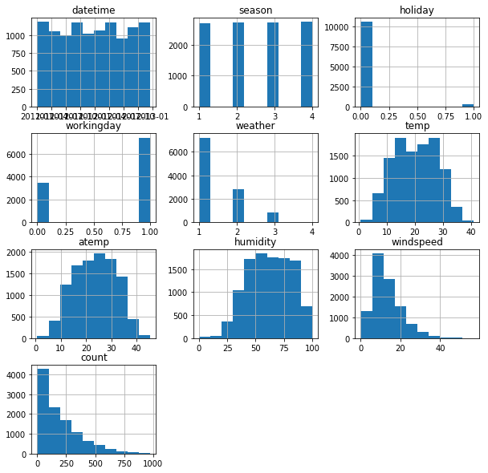

```python
# Create a histogram of all features to show the distribution of each one relative to the data. This is part of the exploritory data analysis
fig = plt.figure(figsize=(10,10))
ax = fig.gca()
train.hist(ax=ax)
plt.show();
```

### Findings from the plot above:

- We can extract time of the day hour and month from datetime column.
- The four seasons have are perfetly balanced with each others, there is no season more that the other.
- There are some features that needs to be with a categoey type such as "season" and "weather" .
- Our target column "count" is right-skewed, it ranges from 0 to almost 1000, but the values are centered under 250.

```python
# create a new features from datetime on train dataset
train["hour"] = train["datetime"].dt.hour
train["day"] = train["datetime"].dt.day
train["month"] = train["datetime"].dt.month

# create a new features from datetime on test dataset
test["hour"] = test["datetime"].dt.hour
test["day"] = test["datetime"].dt.day
test["month"] = test["datetime"].dt.month
```

```python
# Sanity check
train.head(2)
```

|  | datetime | season | holiday | workingday | weather | temp | atemp | humidity | windspeed | count | hour | day | month |
| --- | --- | --- | --- | --- | --- | --- | --- | --- | --- | --- | --- | --- | --- |
| 0 | 2011-01-01 00:00:00 | 1 | 0 | 0 | 1 | 9.84 | 14.395 | 81 | 0.0 | 16 | 0 | 1 | 1 |
| 1 | 2011-01-01 01:00:00 | 1 | 0 | 0 | 1 | 9.02 | 13.635 | 80 | 0.0 | 40 | 1 | 1 | 1 |

## Make category types

```python
train["season"]  = train["season"].astype("category")
train["weather"] = train["weather"].astype("category")
test["season"]   = test["season"] .astype("category")
test["weather"]  = test["weather"].astype("category")
```

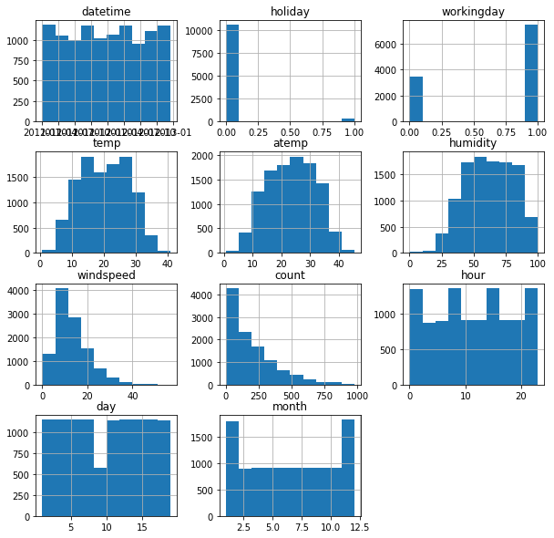

```python
# View histogram of all features again now with the hour feature
fig = plt.figure(figsize=(10,10))
ax = fig.gca()
train.hist(ax=ax)
plt.show();
```

## Step 5: Rerun the model with the same settings as before, just with more features

```python
predictor_new_features = TabularPredictor(label="count").fit(train_data=train, time_limit=600, presets="best_quality")
```

[output not shown]

[output cut: 68 more lines]

```
	Fitting 8 child models (S1F1 - S1F8) | Fitting with ParallelLocalFoldFittingStrategy
	-30.5205	 = Validation score   (-root_mean_squared_error)
	75.34s	 = Training   runtime
	0.14s	 = Validation runtime
Fitting model: ExtraTreesMSE_BAG_L2 ... Training model for up to 5.32s of the 5.31s of remaining time.
	-31.5065	 = Validation score   (-root_mean_squared_error)
	9.17s	 = Training   runtime
	0.61s	 = Validation runtime
Completed 1/20 k-fold bagging repeats ...
Fitting model: WeightedEnsemble_L3 ... Training model for up to 360.0s of the -7.07s of remaining time.
	-30.212	 = Validation score   (-root_mean_squared_error)
	0.33s	 = Training   runtime
	0.0s	 = Validation runtime
AutoGluon training complete, total runtime = 607.63s ... Best model: "WeightedEnsemble_L3"
TabularPredictor saved. To load, use: predictor = TabularPredictor.load("AutogluonModels/ag-20220713_204750/")
```

```python
predictor_new_features.fit_summary()
```

```
*** Summary of fit() ***
Estimated performance of each model:
                     model   score_val  pred_time_val    fit_time  pred_time_val_marginal  fit_time_marginal  stack_level  can_infer  fit_order
0      WeightedEnsemble_L3  -30.211978      21.306552  527.231067                0.000788           0.330328            3       True         15
1          CatBoost_BAG_L2  -30.520522      19.978879  472.152178                0.142388          75.343517            2       True         13
2          LightGBM_BAG_L2  -30.647144      20.379141  422.489343                0.542650          25.680682            2       True         11
3        LightGBMXT_BAG_L2  -31.212184      20.620727  425.876541                0.784235          29.067879            2       True         10
4     ExtraTreesMSE_BAG_L2  -31.506456      20.441735  405.977689                0.605244           9.169028            2       True         14
5   RandomForestMSE_BAG_L2  -31.681273      20.446981  428.096616                0.610490          31.287955            2       True         12
6      WeightedEnsemble_L2  -32.148069      18.745776  351.268084                0.000804           0.550356            2       True          9
7          LightGBM_BAG_L1  -33.916920       3.894665   41.581340                3.894665          41.581340            1       True          4
8          CatBoost_BAG_L1  -34.061203       0.237581  193.204145                0.237581         193.204145            1       True          6
9        LightGBMXT_BAG_L1  -34.520780      13.860931  102.231288               13.860931         102.231288            1       True          3
10    ExtraTreesMSE_BAG_L1  -38.136093       0.562717    7.098161                0.562717           7.098161            1       True          7
11  RandomForestMSE_BAG_L1  -38.404176       0.648175   13.666378                0.648175          13.666378            1       True          5
12   KNeighborsDist_BAG_L1  -84.125061       0.103620    0.034577                0.103620           0.034577            1       True          2
13   KNeighborsUnif_BAG_L1 -101.546199       0.102775    0.040702                0.102775           0.040702            1       True          1
14  NeuralNetFastAI_BAG_L1 -103.033275       0.426028   38.952070                0.426028          38.952070            1       True          8
Number of models trained: 15
Types of models trained:
{'StackerEnsembleModel_XT', 'WeightedEnsembleModel', 'StackerEnsembleModel_LGB', 'StackerEnsembleModel_KNN', 'StackerEnsembleModel_NNFastAiTabular', 'StackerEnsembleModel_CatBoost', 'StackerEnsembleModel_RF'}
Bagging used: True  (with 8 folds)
Multi-layer stack-ensembling used: True  (with 3 levels)
Feature Metadata (Processed):
(raw dtype, special dtypes):
('category', [])             : 2 | ['season', 'weather']
('float', [])                : 3 | ['temp', 'atemp', 'windspeed']
('int', [])                  : 4 | ['humidity', 'hour', 'day', 'month']
('int', ['bool'])            : 2 | ['holiday', 'workingday']
('int', ['datetime_as_int']) : 5 | ['datetime', 'datetime.year', 'datetime.month', 'datetime.day', 'datetime.dayofweek']
Plot summary of models saved to file: AutogluonModels/ag-20220713_204750/SummaryOfModels.html
*** End of fit() summary ***
```

[output not shown]

[output cut: 139 more lines]

```
 0          15
 1          13
 2          11
 3          10
 4          14
 5          12
 6           9
 7           4
 8           6
 9           3
 10          7
 11          5
 12          2
 13          1
 14          8  }
```

```python
# predict on the test data set
predictions_new_features = pd.Series(predictor_new_features.predict(test))
```

```python
# How many negative values do we have?
print("We have {} negative values".format(len(predictions_new_features[predictions_new_features < 0])))
```

```
We have 0 negative values
```

```python
submission_new_features = submission.copy()
submission_new_features["count"] = predictions_new_features
# Set them to zero
submission_new_features["count"] = submission_new_features["count"].apply(lambda x : 0 if (x < 0 ) else x)
submission_new_features.head()
```

|  | datetime | count |
| --- | --- | --- |
| 0 | 2011-01-20 00:00:00 | 15.360823 |
| 1 | 2011-01-20 01:00:00 | 11.099726 |
| 2 | 2011-01-20 02:00:00 | 10.448778 |
| 3 | 2011-01-20 03:00:00 | 9.138494 |
| 4 | 2011-01-20 04:00:00 | 8.037436 |

```python
# Same submitting predictions
submission_new_features.to_csv("submission_new_features.csv", index=False)
```

```python
!kaggle competitions submit -c bike-sharing-demand -f submission_new_features.csv -m "new features"
```

```python
!kaggle competitions submissions -c bike-sharing-demand | tail -n +1 | head -n 6
```

```
fileName                     date                 description                        status    publicScore  privateScore
---------------------------  -------------------  ---------------------------------  --------  -----------  ------------
submission_new_hpo.csv       2022-07-13 18:18:07  new features with hyperparameters  complete  0.45967      0.45967
submission_new_features.csv  2022-07-13 14:34:44  new features                       complete  0.45996      0.45996
submission.csv               2022-07-13 13:20:56  first raw submission               complete  1.78428      1.78428
submission.csv               2022-07-12 23:00:27  first raw submission               complete  1.80657      1.80657
```